# Model Assessment

by Roger Sourm

Model assessment is a very important aspect to statistical and machine learning and there are many, many methods for assessing models such as $R^2$, cross-validation, confusion matrix, root mean square error (RMSE), and mean absolute error, to name a few. This reference document will showcase some model assessment which will help us decide which model or method will give us the best fit or best predictive performance.

# R<sup>2</sup>

R<sup>2</sup>, also known as the *coefficient of determination*, gives information on the goodness of fit of linear models. R<sup>2</sup> is valid only for linear regression and tells us how much of the variability in the response variable is explained by the linear regression and the predictor variables used to fit the model.

The formula for the coefficient of determination is as follow:

$$\begin{aligned}
R^2 &= 1 - \frac{\text{SSE}}{\text{SST}} \\
&= 1 - \frac{\sum_i (y_i - \hat y_i)^2}{\sum_i (y_i - \bar y)^2} \\
& \text{or} \\
&= \frac{SSR}{SST} \\
&= \frac{\sum_i (\hat y_i - \bar y_i)^2}{\sum_i (y_i - \bar y_i)^2}
\end{aligned}$$

where

- SSE = sum of squares error
- SST = sum of squares total
- $y_i$ = value of the i<sup>th</sup> response variable
- $\hat y$ = predicted value of the i<sup>th</sup> response variable
- $\bar y$ = overall average of the response variable
- SSR = sum of squares regression

The value of R<sup>2</sup> takes on a percentage between 0 and 1. If $R^2 = 1$, all of the variability in the $y$ values is explained by the $x$ values.If $0<R^2<1$, 0.53 for example, then $53\%$ of the variability in the $y$ values is explained by the $x$ values. If $R^2 = 0$, none of the variability in the $y$ values is explained by the $x$ values. Generally, the higher the R<sup>2</sup>, the better the fit.

Let us consider the set of points: {(0, 0), (1, 1), (2, 2), (3, 3), (4, 4), (5, 5)}. Looking at the set of data points or visually on a plot, we can easily see that the slope is 1. For every one-unit increase in x, there is a one-unit increase in y.

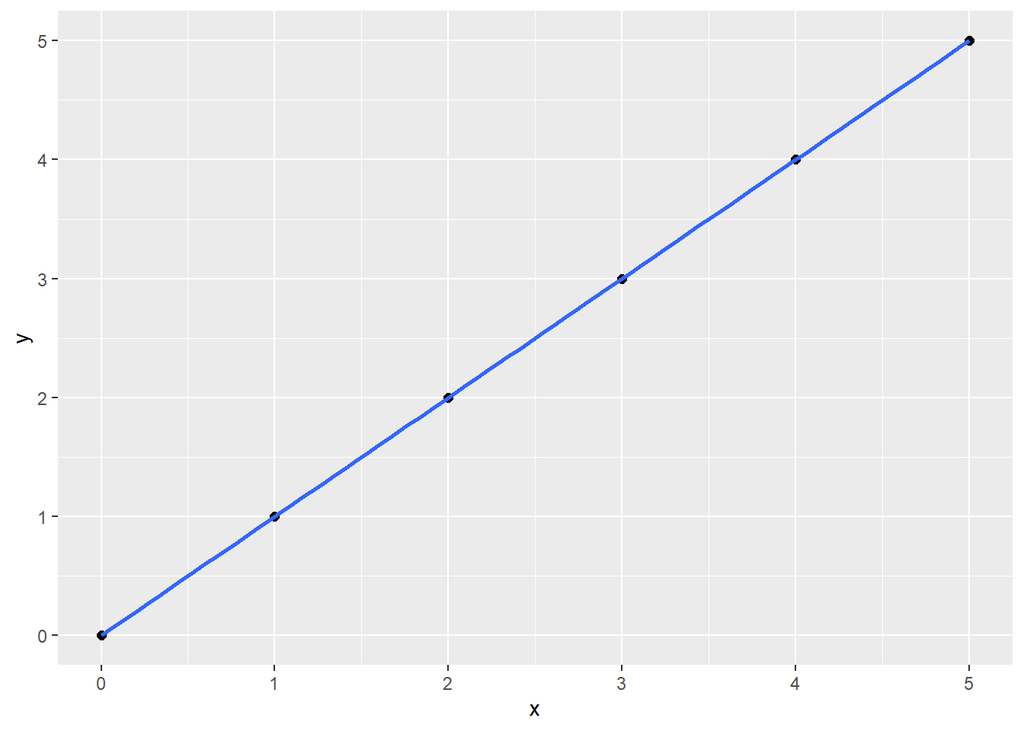

```r
df1 <- data.frame(x = 0:5, y = 0:5)

ggplot(data = df1, aes(x = x, y = y)) +
  geom_point(size = 2) +
  geom_smooth(method = "lm", se = FALSE)
```

And if we were to fit a linear regression model to the data (which would fit the line from the plot above), intuitively we should understand that R<sup>2</sup> is going be 1 since all of the points fall along the straight line.

```r
r.sq_lm <- lm(y ~ x, data = df1)
summary(r.sq_lm)
```

```
##
## Call:
## lm(formula = y ~ x, data = df1)
##
## Residuals:
##          1          2          3          4          5          6
##  6.428e-16 -1.039e-15  1.864e-16  2.669e-16 -1.522e-16  9.483e-17
##
## Coefficients:
##               Estimate Std. Error    t value Pr(>|t|)
## (Intercept) -7.252e-16  4.620e-16 -1.570e+00    0.192
## x            1.000e+00  1.526e-16  6.553e+15   <2e-16 ***
## ---
## Signif. codes:  0 '***' 0.001 '**' 0.01 '*' 0.05 '.' 0.1 ' ' 1
##
## Residual standard error: 6.384e-16 on 4 degrees of freedom
## Multiple R-squared:      1,  Adjusted R-squared:      1
## F-statistic: 4.294e+31 on 1 and 4 DF,  p-value: < 2.2e-16
```

Now consider this set: {(0, 0), (1, 1), (2, 2), (3, 4), (4, 5), (5, 6)}.

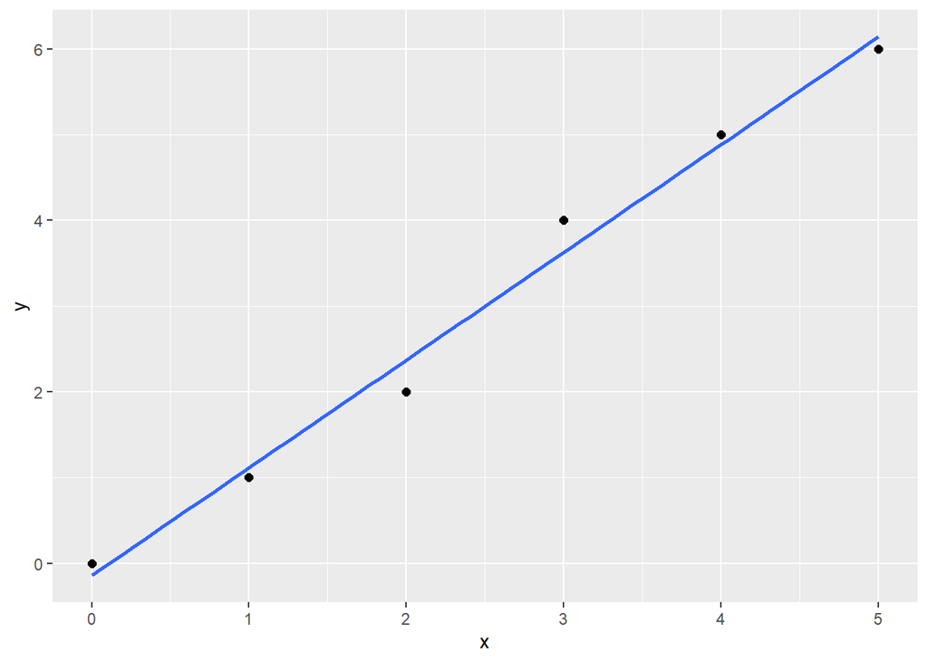

```r
df2 <- data.frame(x = 0:5,
                  y = c(0:2, 4:6))

ggplot(data = df2, aes(x = x, y = y)) +
  geom_point(size = 2) +
  geom_smooth(method = "lm", se = FALSE)
```

We can see that the data points in this set does not fall perfectly on the regression line built upon the data points. Because of this, we should intuitively know that R<sup>2</sup> won’t equal 1, but since the line seems to fit the data points well, it should be pretty high.

```r
r.sq_lm2 <- lm(y ~ x, data = df2)
summary(r.sq_lm2)
```

```
##
## Call:
## lm(formula = y ~ x, data = df2)
##
## Residuals:
##       1       2       3       4       5       6
##  0.1429 -0.1143 -0.3714  0.3714  0.1143 -0.1429
##
## Coefficients:
##             Estimate Std. Error t value  Pr(>|t|)
## (Intercept) -0.14286    0.21189  -0.674     0.537
## x            1.25714    0.06999  17.963 0.0000565 ***
## ---
## Signif. codes:  0 '***' 0.001 '**' 0.01 '*' 0.05 '.' 0.1 ' ' 1
##
## Residual standard error: 0.2928 on 4 degrees of freedom
## Multiple R-squared:  0.9878, Adjusted R-squared:  0.9847
## F-statistic: 322.7 on 1 and 4 DF,  p-value: 0.00005646
```

Lastly, consider this set: {(0, 2), (1, 0), (2, 2), (3, 0), (4, 2), (5, 0)}.

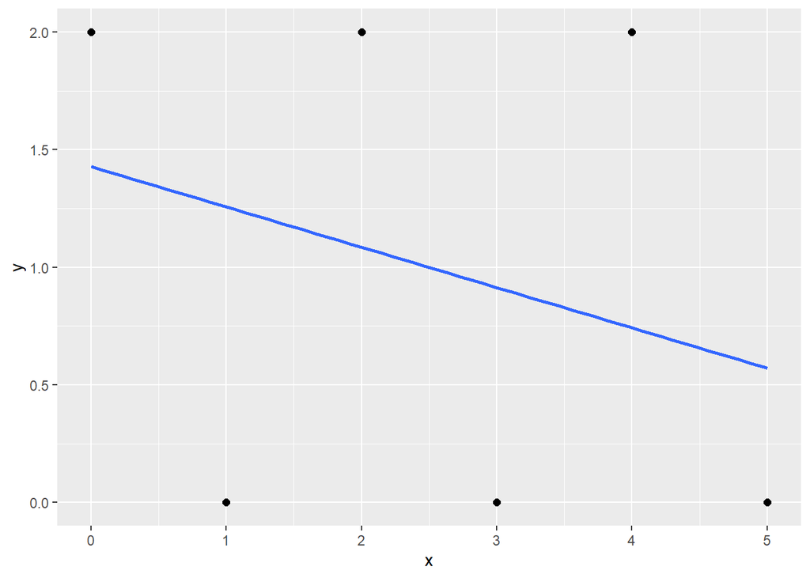

```r
df3 <- data.frame(x = 0:5,
                  y = rep(c(2,0), 3))

ggplot(data = df3, aes(x = x, y = y)) +
  geom_point(size = 2) +
  geom_smooth(method = "lm", se = FALSE)
```

```r
r.sq_lm3 <- lm(y ~ x, data = df3)
summary(r.sq_lm3)
```

```
##
## Call:
## lm(formula = y ~ x, data = df3)
##
## Residuals:
##       1       2       3       4       5       6
##  0.5714 -1.2571  0.9143 -0.9143  1.2571 -0.5714
##
## Coefficients:
##             Estimate Std. Error t value Pr(>|t|)
## (Intercept)   1.4286     0.8476   1.685    0.167
## x            -0.1714     0.2799  -0.612    0.573
##
## Residual standard error: 1.171 on 4 degrees of freedom
## Multiple R-squared:  0.08571,    Adjusted R-squared:  -0.1429
## F-statistic: 0.375 on 1 and 4 DF,  p-value: 0.5734
```

It is obvious that the linear regression line does not fit the data well. This is supported by the fact that the value for the coefficient of determination is a mere 0.08571.

# Root Mean Square Error (RMSE)

The root mean square error, or RMSE, is a popular metric for evaluating the performance of regression models. To determine the RMSE, we use test sets to essentially find the variations in the differences between the actual values of the response variable and the predicted values of the response variable. The RMSE is a great tool for comparing models and the lower the RMSE, the better the predictive performance.

Use the following formula to evaluate for the RMSE:

$$\text{RMSE} =
\sqrt{\frac{\sum_{i=1}(y_i-\hat y_i)^2}{n}}$$

where

- $y_i$ = sale price of the i<sup>th</sup> observation.
- $\hat y_i$ = predicted sale price of the i<sup>th</sup> observation.
- n = the number of observations.

To put it simply, we make a prediction for the sale price for each row of the test set. We subtract this predicted sale price from the actual sale price and square the results to avoid any issues with negative values. Then average the squared errors. Lastly, we square root the averaged squared error. Hence, root mean square error.

The following code will define a function for the RMSE:

```r
# Defining the RMSE function.
RMSE <- function(y, y_hat){
  sqrt(mean((y - y_hat)^2))
}
```

All we have to do is supply the values of the actual response variable and the values of the prediction.

Examples of the RMSE will be covered in the next section.

# Cross-Validation

Cross-validation involves splitting the data set into a training set and a test set. The training set is used to fit the model. We then make predictions using the test set and compare the predictions to the actual response variable of the test set. In doing so, we can determine the predictive performance of the model.

There is no set rule to how large the training set and the test set should be, but a commonly use split is a 70/30 or 80/20 train/test split.

There are other cross-validation techniques such as a k-fold cross-validation which takes the whole data set and splits it into k equal parts. One of those k parts becomes the test set while the other k - 1 parts become the training set. With k-fold cross-validation, there will be k iterations which cycles each k<sup>th</sup> part as the test set. The predictive performance is then averaged out between the k iterations.

Examples of cross-validation will be performed on the `ames` data set from the `AmesHousing` package. We will fit a simple linear regression model to predict the sale price (`Sale_Price`) based off of the total ground square footage (`Gr_Liv_Area`).

## Simple Cross-Validation (70/30 & 80/20)

To create a split, we will assign the number of observations in the data set to a variable. We will use `n`. We will then use the `sample()` function in the following format: `sample(1:n, n * [proportion of data set to be the training set])`. The `sample()` function will randomly select numbers from 1 to `n` and the amount of numbers selected will be `n` times the supplied proportion. We will assign these numbers to the variable `index` to which we will use to index our data set, creating the training set. To obtain the test set, we just have to index our data set with `-index`. We will see an example of both a 70/30 and 80/20 train/test split.

```r
# Data.
ames <- make_ames()
ames2 <- ames %>% select(Sale_Price,Gr_Liv_Area)

# Getting the number of row.
n <- nrow(ames2)
```

70/30 split:

```r
# 70/30 split.
set.seed(123) # For reproducibility.
index70_30 <- sample(1:n, n*0.7)
train_ames_70 <- ames2[index70_30, ]
test_ames_30 <- ames2[-index70_30, ]
```

80/20 split:

```r
# 80/20 split.
set.seed(123) # For reproducibility.
index80_20 <- sample(1:n, n*0.8)
train_ames_80 <- ames2[index80_20, ]
test_ames_20 <- ames2[-index80_20, ]
```

Creating any desired split is simple. Whatever percentage of the data set we want to become the training set, we’d just multiply that to `n`, the number of rows in our data set, within the `sample()` function. So if you’d want to create a 33/63 split, the code to create the index simply would be `sample(1:n, n*0.33)` (although I would not advise to create a test set bigger than the training set). We can now fit the model to the training sets.

```r
# Fitting the training set to a the 70 training set.
lm1 <- lm(Sale_Price ~ Gr_Liv_Area,
          data = train_ames_70)

# Fitting the training set to a the 80 training set.
lm2 <- lm(Sale_Price ~ Gr_Liv_Area,
          data = train_ames_80)
```

### Comparing the 70/30 & 80/20 Split

After creating the models, we will make prediction using the corresponding test set so that we can assess the model’s performance. We will assess the models by looking at their R<sup>2</sup> values as well as the RMSE. These metrics will give us insight to which model fits the data better as well as which has a better predictive performance.

```r
# Predictions using the 30 and 20 test set.
pred1 <- predict(lm1, newdata = test_ames_30)
pred2 <- predict(lm2, newdata = test_ames_20)
```

70/30 Linear Model Summary:

```r
summary(lm1)
```

```
##
## Call:
## lm(formula = Sale_Price ~ Gr_Liv_Area, data = train_ames_70)
##
## Residuals:
##     Min      1Q  Median      3Q     Max
## -478762  -30030   -1405   22273  335855
##
## Coefficients:
##              Estimate Std. Error t value Pr(>|t|)
## (Intercept) 14045.872   3942.503   3.563 0.000375 ***
## Gr_Liv_Area   110.726      2.506  44.185  < 2e-16 ***
## ---
## Signif. codes:  0 '***' 0.001 '**' 0.01 '*' 0.05 '.' 0.1 ' ' 1
##
## Residual standard error: 57430 on 2049 degrees of freedom
## Multiple R-squared:  0.4879, Adjusted R-squared:  0.4877
## F-statistic:  1952 on 1 and 2049 DF,  p-value: < 2.2e-16
```

70/30 Linear Model RMSE:

```r
RMSE(test_ames_30$Sale_Price, pred1)
```

```
## [1] 54378.11
```

80/20 Linear Model Summery:

```r
summary(lm2)
```

```
##
## Call:
## lm(formula = Sale_Price ~ Gr_Liv_Area, data = train_ames_80)
##
## Residuals:
##     Min      1Q  Median      3Q     Max
## -484734  -29698   -1375   22843  334520
##
## Coefficients:
##              Estimate Std. Error t value Pr(>|t|)
## (Intercept) 12036.423   3632.983   3.313 0.000937 ***
## Gr_Liv_Area   112.141      2.309  48.560  < 2e-16 ***
## ---
## Signif. codes:  0 '***' 0.001 '**' 0.01 '*' 0.05 '.' 0.1 ' ' 1
##
## Residual standard error: 56840 on 2342 degrees of freedom
## Multiple R-squared:  0.5017, Adjusted R-squared:  0.5015
## F-statistic:  2358 on 1 and 2342 DF,  p-value: < 2.2e-16
```

80/20 Linear Model RMSE:

```r
RMSE(test_ames_20$Sale_Price, pred2)
```

```
## [1] 55245.27
```

## k-Fold Cross-Validation

Performing k-fold cross-validation means performing k iterations of fitting and testing. Each iteration is known as a fold. The more we fit and test, the more accurate the performance assessment gets. You can think of this as somewhat like re-sampling. With re-sampling, we draw many samples from a set to which we aggregate the result to obtain an estimate of the population mean. With k-fold, we train and fit k times to which we then average the performance assessment.

The value for k is arbitrary, but $k = 10$ is commonly used. There are procedures that can be done to find the optimal value for k and this concept falls under parameter tuning, but we won’t get into that here. We will only showcase the usage of k-fold cross-validation.

To perform k-fold cross-validation, we will use the `train()` function from the `caret` package. To use a 10-fold cross-validation, we supply the `trControl` parameter with the argument `trainControl(method = "cv", number = 10)`.

```r
library(caret)
set.seed(123) # For reproducibility.
ten_cv_model1 <- train(
  Sale_Price ~ Gr_Liv_Area,
  data = ames2,
  method = "lm",
  trControl = trainControl(method = "cv",
                           number = 10)
)
```

If you want to look at the RMSE, R<sup>2</sup>, and MAE of each of the models in the $k = 10$ folds, we just call the `resample` attribute of the fitted model.

```r
ten_cv_model1$resample
```

```
##        RMSE  Rsquared      MAE Resample
## 1  58299.81 0.4530997 37793.28   Fold01
## 2  59778.15 0.3588099 39127.78   Fold02
## 3  52774.63 0.5308935 37861.17   Fold03
## 4  53541.33 0.6135187 37127.90   Fold04
## 5  54454.16 0.5016460 38802.40   Fold05
## 6  51485.27 0.5734780 37712.46   Fold06
## 7  56242.22 0.5436006 38339.59   Fold07
## 8  57558.54 0.4691869 39728.80   Fold08
## 9  57074.82 0.5284317 40513.13   Fold09
## 10 63938.03 0.4580979 38694.79   Fold10
```

And if we average these values, we get:

```r
sapply(ten_cv_model1$resample[, 1:3], mean)
```

```
##          RMSE      Rsquared           MAE
## 56514.6962341     0.5030763 38570.1302391
```

We can see that these values correspond to the performance metric values of the model.

NOTE: MAE stands for mean absolute error and the formula for it is $\frac{\sum_{i=1}^n|y_i - \hat y_i|}{n}$.

```r
ten_cv_model1
```

```
## Linear Regression
##
## 2930 samples
##    1 predictor
##
## No pre-processing
## Resampling: Cross-Validated (10 fold)
## Summary of sample sizes: 2637, 2637, 2637, 2636, 2637, 2638, ...
## Resampling results:
##
##   RMSE     Rsquared   MAE
##   56514.7  0.5030763  38570.13
##
## Tuning parameter 'intercept' was held constant at a value of TRUE
```

Although k-fold cross-validation has its benefits, implementing it may be costly. Due to the nature of k-fold cross-validation fitting and testing k times, the time it takes to perform the k-fold cross-validation increases as the size of the data set increases.

We will duplicate the `Ames` data 100 times and combine them to make a bigger `Ames` data set. We will record how long it takes to fit a model trained to a data set with 2,930 rows (original `Ames`) as well as a model trained to the bigger `Ames` data set (293,000 rows).

```r
# Run time for 10-fold CV with n = 2,930.
set.seed(123) # For reproducibility.
start_time1 <- Sys.time()
ten_cv_model1 <- train(
  Sale_Price ~ Gr_Liv_Area,
  data = ames2,
  method = "lm",
  trControl = trainControl(method = "cv",
                           number = 10)
)
end_time1 <- Sys.time()

# Creating the bigger Ames (100x duplication).
big_ames <- c()
for(i in 1:100){
  big_ames <- rbind(big_ames, ames2)
}

# Run time for 10-fold CV with n = 293,000.
set.seed(123) # For reproducibility.
start_time2 <- Sys.time()
big_cv_model1 <- train(
  Sale_Price ~ Gr_Liv_Area,
  data = big_ames,
  method = "lm",
  trControl = trainControl(method = "cv",
                           number = 10)
)
end_time2 <- Sys.time()
```

```r
print("n = 2,930")
```

```
## [1] "n = 2,930"
```

```r
end_time1 - start_time1
```

```
## Time difference of 0.1900179 secs
```

```r
print("n = 293,000")
```

```
## [1] "n = 293,000"
```

```r
end_time2 - start_time2
```

```
## Time difference of 9.496197 secs
```

Although 9.496197 seconds isn’t really a long wait-time, it was a 49.9752658 multiplier of the time it took the 10-fold cross-validation to execute when `n = 2930` ( 0.1900179 seconds). With this example, we can understand that data sets with even larger number of observations can cause a significant increase to the run time of performing k-fold cross-validation.

# Confusion Matrix

A confusion matrix is a $N\times N$ table that compares actual values to predicted values. $N$ is the number of possible choices for the response variable. A confusion matrix constructed with a binary response variable means that $N=2$ and the table will result in a $2\times 2$ matrix. If $N=3$, then the confusion matrix would be a $3\times 3$ table.

Confusion matrices are used to assess classification. It provides us information such as the accuracy, sensitivity, specificity, and misclassification rate.

$$\text{Accuracy}: \frac{TP+TN}{Total}$$

where

- TP = True positives (correctly identified positives)
- TN = True negatives (correctly identified negatives)
- Total = Total number

$$\text{Sensitivity}: \frac{TP}{P}$$

where

- P = Total number of positives

$$\text{Specificity}: \frac{TN}{N}$$

where

- N = Total number of negatives

$$\text{Misclassification Rate}: 1 - \text{Accuracy} = 1 - \frac{TP +
TN}{Total}$$

Accuracy is simply the percentage that was correctly predicted. Sensitivity is the percentage of correctly classified positives. Specificity is the percentage of correctly classified negatives. Misclassification rate is the percentage that was incorrectly predicted.

Depending on the experiment, a higher sensitivity could be more important, while in other cases, a higher specificity could be more important. It all depends on the experimenter and specifications of their experiment.

## $2 \times 2$ Confusion Matrix Example

Consider this table as the example confusion matrix.

```
##           Actual
## Prediction  No Yes Sum
##        No   95  23 118
##        Yes  47 769 816
##        Sum 142 792 934
```

It is up to the individual to decide if No’s are negatives and Yes’s are positives. Depending on the question, maybe No’s are positives and Yes’s are negatives. In our example, we will consider No’s as negatives.

$\text{Accuracy} = \frac{769+95}{934}\approx0.9251$.

$\text{Sensitivity} = \frac{769}{792}\approx0.9710$.

$\text{Specificity} = \frac{95}{142}\approx0.6690$.

## $3 \times 3$ Confusion Matrix Example

Consider the confusion matrix which the prediction were made by a multinomial logistic regression. The model attempts to predict whether a flower is one of these three species, setosa, versicolor, or virginica. The model was fitted using the length and width of both the sepal and petal (`Sepal.Length`, `Sepal.Width`, `Petal.Length`, `Petal.Width`) of the flower. The following is the confusion matrix constructed from the actual value and the predicted values of the multinomial logistic regression model.

```r
n_CM <- nrow(iris)

# Cross-validation.
set.seed(123) # For reproducibility.
index_CM <- sample(1:n_CM, n_CM * 0.8)
train_iris <- iris[index_CM, ]
test_iris <- iris[-index_CM, ]


# Fitting the multinomial logistic regression.
library(nnet)
mlm1 <- multinom(Species ~ ., data = train_iris, trace = FALSE)

# Making predictions on the test set.
mlm1_pred <- predict(mlm1, newdata = test_iris)

# Confusion matrix.
mlm1_cm <- table(Prediction = mlm1_pred,
                 Actual = test_iris$Species)
addmargins(mlm1_cm)
```

```
##             Actual
## Prediction   setosa versicolor virginica Sum
##   setosa         10          0         0  10
##   versicolor      0         14         0  14
##   virginica       0          1         5   6
##   Sum            10         15         5  30
```

$\text{Accuracy} = \frac{10+14+5}{30}\approx0.9667$.

$\text{Sensitivity}_{\text{setosa}} = \frac{10}{10}=1$.

$\text{Specificity}_{\text{setosa}} = \frac{14+1+0+5}{15+5}=1$.

$\text{Sensitivity}_{\text{versicolor}} = \frac{14}{15}\approx0.9333$.

$\text{Specificity}_{\text{versicolor}} = \frac{10+0+0+5}{10+5}=1$.

$\text{Sensitivity}_{\text{virginica}} = \frac{5}{5}=1$.

$\text{Specificity}_{\text{virginica}} = \frac{10+0+0+14}{10+15}=0.96$.

$\text{Misclassification Rate} = 1 - 0.9667 = 0.0333$.

# Ending Notes

Model assessment is very important and it allows us to choose the model that performs better. There are many methods for model assessment and more will be added to this reference when I learn them.